# LabAssignment07_EP_SampleSolution

## Lab Assignment 7

Please fill this notebook with your code and explainations, run everything, save the notebook and upload to canvas.

This lab assignment contains *`TWO`* problems. Read each problem carefully and answer them the best you can.

Be sure to provide an explaination to your work using a comment.

### Problem 1

Create the following 3 by 3 matrix (multi-dimensional array) using the numpy module.

```
1   2   3
5   6   7
9  10  11
```

You may use for loops but you can also do it using vectorization.

```python
# For Problem 1:
np.array(range(9)).reshape((3,3)) + np.array([[1],[2],[3]])
```

```
array([[ 1,  2,  3],
       [ 5,  6,  7],
       [ 9, 10, 11]])
```

### Problem 2

Plot the following function g(x) for $x$ in $[-\pi,\pi]$ using **matplotlib** and **numpy** (and exactly 1000 points). Use the **math** module to import $\pi$.

$ g(x) = \begin{cases} x^{2}\sin\left(x^{3}\right) & \quad \text{if } x \neq 0\\ 0 & \quad \text{if } x = 0\\ \end{cases}$

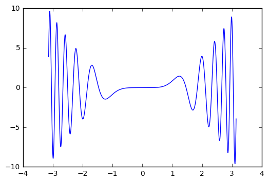

```python
# For Problem 2.
import matplotlib.pyplot as plt
%matplotlib inline
import numpy as np
from math import pi

xs = np.linspace(-pi, pi, 1000)
def g(x):
    return x**2*np.sin(x**3)
plt.plot(xs,g(xs))
```

### Problem 3 (not graded but very important)

You are given the following numpy array which contains stock prices for the last five days.

```python
# For Problem 3
import numpy as np
names = ["AAPL", "GOOGL", "TSLA", "NVDA"]
# each row is a company
X = np.array([[135.55, 135.30, 136.26, 136.63, 137.20],
              [838.97, 845.83, 851.24, 848.50, 850.01],
              [279.25, 270.67, 268.04, 278.88, 275.53],
              [108.24, 106.83, 107.14, 110.52, 110.64]])
```

```python
# For Problem 3
means = np.apply_along_axis(np.mean, 1, X[:,2:])
np.array(list(zip(names, means)))   # but you could also use a loop or list comprehension
```

```
array([['AAPL', '136.696666667'],
       ['GOOGL', '849.916666667'],
       ['TSLA', '274.15'],
       ['NVDA', '109.433333333']],
      dtype='<U13')
```

- Say four new days of data are given to you as a numpy array called Y. What would the shape of Y be? How would you make a new array for all the prices together? Remark: you can use slicing to set things too, like `X[0,:] = Z[3,:]` will make X's 0th row be set to Z's 3rd row.

```python
Y = np.array([[139.,140.,141., 144.],[840., 841., 838., 836], [276., 276., 277., 280], [110., 108., 107., 109]])
```

Each row was a company, and each column was a day, so we need to add four new columns to the matrix.

```python
Z = np.zeros([4, 9])

Z[:,0:5] = X[:,:]
Z[:,5:9] = Y[:,:]
```

```python
print(Z)
```

```
[[ 135.55  135.3   136.26  136.63  137.2   139.    140.    141.    144.  ]
 [ 838.97  845.83  851.24  848.5   850.01  840.    841.    838.    836.  ]
 [ 279.25  270.67  268.04  278.88  275.53  276.    276.    277.    280.  ]
 [ 108.24  106.83  107.14  110.52  110.64  110.    108.    107.    109.  ]]
```